Tài liệu này mang giấy phép Creative Commons Attribution (CC BY). (c) Nguyễn Ngọc Sáng, Zhukovsky 12/2018.

[@SangVn](https://github.com/SangVn) [@VnCFD](https://vncfdgroup.wordpress.com/)

*Thực hành CFD với Python!*

# Bài 16. Hệ phương trình Euler, bài toán Riemann, phân rã gián đoạn Godunov

[[Godunov - Phương pháp số giải các bài toán Khí động lựa học nhiều chiều](https://vncfdgroup.wordpress.com/2013/03/21/gioi-thieu-phuong-phap-so-de-giai-cac-bai-toan-khi-dong-luc-hoc-nhieu-chieu-cua-godunov-s-k/)]

Yous Van Halder - Godunov method for the Euler Equations

# 1. Phương trình Euler

Dòng chảy lưu chất không nhớt được mô tả bởi hệ phương trình Euler. Hệ phương trình đối với dòng chảy một chiều có dạng: $$\frac{\partial U}{\partial t} + \frac{\partial F}{\partial x} = 0 \qquad(1)$$ trong đó: \begin{align} U & = \begin{pmatrix} \rho \\ \rho u \\ \rho e\end{pmatrix}, & F & = \begin{pmatrix} \rho u \\ \rho u^2 + p \\ \rho ue + pu\end{pmatrix}. \end{align}

với $\rho$ - khối lượng riêng, $u$ - vận tốc theo phương x, $p$ - áp suất, $e$ - năng lượng một đơn vị khối lượng lưu chất. Năng lượng $e$ gồm hai thành phần: nội năng $\varepsilon$ và động năng $u^2/2$: $$e = \varepsilon + \frac{u^2}{2}$$ Ta thấy có ba phương trình nhưng có tới 4 ẩn. Để 'khép kín' hệ ta sử dụng thêm phương trình trạng thái: $$p=p(\rho, \varepsilon)$$ Đối với khí lý tưởng: $$p = (\gamma-1)\rho\varepsilon \qquad (2)$$ với $\gamma$ là số mũ đoạn nhiệt. Trường hợp khí là không khí (xem như khí hai nguyên tử) thì $\gamma=1.4$.

Phương trình Euler mô tả ba định luật bảo toàn khối lượng, động lượng và năng lượng. Trong trường hợp dòng chảy ba chiều ta có thêm hai thành phần vận tốc $v$ và $w$, hệ có dạng:

$$\frac{\partial U}{\partial t} + \frac{\partial F}{\partial x} + \frac{\partial G}{\partial x} +\frac{\partial H}{\partial x} = 0\qquad(3)$$

với \begin{align} U & = \begin{pmatrix} \rho \\ \rho u \\ \rho v \\ \rho w \\ \rho e\end{pmatrix}, & F & = \begin{pmatrix} \rho u \\ \rho u^2 + p \\ \rho u v \\ \rho u w \\ \rho ue + pu\end{pmatrix} & G & = \begin{pmatrix} \rho v \\ \rho uv \\ \rho v^2 + p \\ \rho v w \\ \rho ve + pv\end{pmatrix} & H & = \begin{pmatrix} \rho w \\ \rho uw \\ \rho vw \\ \rho w^2 + p \\ \rho we + pw\end{pmatrix}. \end{align} và $e = \varepsilon + \frac{u^2+v^2+w^2}{2}$

Chúng ta đã giải phương trình Burger cũng có dạng giống phương trình (1). Để giải hệ phương trình Euler 1D cảm giác như chỉ cần thay u vô hương trong phương trình Burger bằng vector U là ổn. Thế nhưng mọi thứ không đơn giản như vậy. Mấu chốt vấn đề là giải quyết bài toán phân rã gián đoạn trên bề mặt thể tích kiểm soát hay là bài toán Riemann như thế nào. Godunov chính là người đầu tiên đưa ra lời giải chính xác cho bài toán này (1959).

# 2. Phân rã gián đoạn Godunov

Xét bài toàn Riemann trong động lực học lưu chất: $$U_t + F(U)_x = 0 \qquad (4)\\ U(t=0)= \begin{cases} U_L(\rho_L, u_L, p_L); \quad x<x_0 \\ U_R(\rho_R, u_R, p_R); \quad x>x_0 \end{cases} $$

## Biến bảo toàn

Phương trình (1) hay (4) được viết dưới dạng bảo toàn (dạng phân kì) cho biến bảo toàn U và dòng F. Ma trận Jacobian $A=\frac{\partial F}{\partial U}$:

$$A= \begin{pmatrix} 0 & 1 &0\\ \frac{1}{2}(\gamma-3)u^2 & (3-\gamma)u & (\gamma-1) \\ \frac{1}{2}(\gamma-2)u^3-\frac{c^2u}{\gamma-1} & \frac{c^2}{\gamma-1}+(\frac{3}{2}-\gamma)u^2 & \gamma u \end{pmatrix} $$

với `vận tốc âm thanh` $$c=\sqrt{\frac{\gamma p}{\rho}}$$

Matrận A có 3 giá trị riêng: $$\lambda_1 = u-c, \lambda_2 = u, \lambda_3 = u+c$$ Với 3 trị riêng $\lambda_1<\lambda_2<\lambda_3$, hệ phương trình có dạng hyperbolic. Tương ứng ta có 3 vector riêng:

$$ \begin{align} R_1 & = \begin{pmatrix} 1\\ u-c \\ H-uc \end{pmatrix} & R_2 & = \begin{pmatrix} 1\\ u \\ u^2 \end{pmatrix} & R_3 & = \begin{pmatrix} 1\\ u+c \\ H+uc \end{pmatrix} \end{align} $$

Với H là enthalpy: $$H = \frac{\rho(\varepsilon + u^2/2) + p}{\rho}=\frac{1}{2}u^2+\frac{c^2}{\gamma-1}$$

# Biến nguyên thủy (biến gốc)

Phương trình (1) có thể viết lại ở dạng không bảo toàn (dạng không phân kì - xem bài 12) cho biến nguyên thủy $P=(\rho, u, p)$. Khi đó ma trận Jacobian:

$$A= \begin{pmatrix} u & \rho & 0\\ 0 & u & \frac{1}{\rho} \\ 0 & \rho c^2 & u \end{pmatrix} $$

có 3 trị riêng: $$\lambda_1 = u-c, \lambda_2 = u, \lambda_3 = u+c$$ 3 vector riêng: $$ \begin{align} R_1 & = \begin{pmatrix} 1\\ -\frac{c}{\rho} \\ c^2 \end{pmatrix} & R_2 & = \begin{pmatrix} 1\\ 0 \\ 0 \end{pmatrix} & R_3 & = \begin{pmatrix} 1\\ \frac{c}{\rho} \\ c^2 \end{pmatrix} \end{align} $$

Ba trị riêng tương ứng với 3 gián đoạn, với $\lambda_2 = u$ không phụ thuộc $\rho, p$ - gián đoạn này gọi là gián đoạn tiếp xúc, hai gián đoạn còn lại có thể là sóng xung kích hoặc sóng giãn. Ta có cấu hình gián đoạn như sau:

[figure not shown]

Bốn cấu hình đầu tiên đều chứa gián đoạn tiếp xúc, tại đây khối lượng riêng bị 'gián đoạn' còn vận tốc và áp suất thì 'liên tục'. Giá trị của chúng bên trái và phải như nhau ta kí hiệu là $P, U$. Còn khối lượng riêng và nội năng ở bên trái, phải ta kí hiệu $R_I, E_I$ và $R_{II}, E_{II}$. Hai vùng trái phải ngoài cùng là vùng không nhiễu động với các thông số $(p_I, \rho_I, u_I), (p_{II}, \rho_{II}, u_{II})$. Cấu hình cuối cùng là trường hợp xuất hiện `vùng chân không` giữa hai sóng giãn, nơi khối lượng giảm xuống bằng 0.

**Phương pháp giải:**

Quá trình biến đổi toán học các bạn tìm hiểu thêm trong quyển sách của Godunov. Phương pháp giải được tóm tắt như sau: Giả sử gián đoạn lan truyền với vận tốc $D=dx/dt$. Áp dụng định luật bảo toàn cho một thể tích hữu hạn bao quanh một đoạn đường gián đoạn ta có: $$ [\rho]D - [\rho u] = 0 \qquad (I)\\ [\rho u]D - [p+\rho u^2] = 0 \qquad(II)\\ [\rho(\varepsilon+u^2/2)]D - [\rho u(\varepsilon+u^2/2)+pu] = 0 \qquad(III) $$ với kí hiệu [] - chênh lệnh giá trị hai bên gián đoạn. Đối với sóng xung kích, biến đổi ta được: $$E-\varepsilon-\frac{1}{2}(1/\rho-1/R)(p+P) = 0$$ với $(p,\rho, \varepsilon)$ - đại lượng phía trước sóng xung kích, $(P, R, E)$ - phía sau sóng xung kích. Loại bỏ nội năng bằng phương trình trạng thái ta thu được điều kiện **Rankine–Hugoniot**: $$R=\rho\frac{(\gamma+1)P + (\gamma-1)p}{(\gamma-1)P + (\gamma+1)p}$$

Xét sóng xung kích bên trái, từ phương trình (I, II, III) ta có mật độ dòng khối lượng hay vận tốc khối lượng: $$a_I = \rho_I(u_I-D_I) = R_I(U-D_I)$$ Biến đổi ta được: $$U - u_I + \frac{P-p_I}{a_I} = 0$$ $$a_I = \sqrt{\rho_I(\frac{\gamma+1}{2}P +\frac{\gamma-1}{2}p_{I})} \qquad(8)$$

Đối với sóng xung kích bên phải:

$$a_{II} = \rho_{II}(D_{II}-u_{II}) = R_{II}(D_{II}-U)$$$$U - u_{II} - \frac{P-p_{II}}{a_{II}} = 0$$$$a_{II} = \sqrt{\rho_{II}(\frac{\gamma+1}{2}P +\frac{\gamma-1}{2}p_{II})} \qquad(9)$$

Trường hợp sóng giãn trái, phải: $$a_{I} = \frac{\gamma-1}{2\gamma}\rho_Ic_I\frac{1-P/p_{I}}{1-(P/p_{I})^{(\gamma-1)/(2\gamma)}} \qquad(10)$$ $$a_{II} = \frac{\gamma-1}{2\gamma}\rho_{II}c_{II}\frac{1-P/p_{II}}{1-(P/p_{II})^{(\gamma-1)/(2\gamma)}}\qquad(11)$$ Việc đầu tiên chúng ta cần làm đó là xác định áp suất P. Có hai cách để tìm nghiệm P chính xác: phương pháp lặp và giải phương trình f(P) = 0. Ngoài ra còn có các phương pháp xấp xỉ để tìm P.

**Phương pháp lặp:**

Giả sử $P^{n-1}$ là nghiệm gần đúng của P ($P^0$ tại thời điểm ban đầu cho trước). Khi đó $a_{I}^{n-1}$ tính theo công thức (8) nếu $P^{n-1} \geq p_I$, theo công thứ (10) nếu ngược lại, còn giá trị $a_{II}^{n-1}$ tính theo công thức (9) nếu $P^{n-1} \geq p_{II}$ và theo công thức (11) nếu ngược lại.

Sau đó giá trị $P^n$ xác định theo công thức: $$P^n = \varphi(P^{n-1})=\frac{a_{II}p_I + a_Ip_{II}+a_Ia_{II}(u_I-u_{II})}{a_I+a_{II}}$$

Tiếp tục quá trình lặp cho tới khi nghiệm hội tụ.

Kiểm chứng cho thấy nghiệm hội tụ khi sau phân rã không xuất hiện sóng giãn rất mạnh. Do đó ta thay đổi quá trình lặp như sau để phù hợp với mọi trường hợp:

$$P^n=\frac{\alpha_{n-1}P^{n-1} + \varphi(P^{n-1})}{1+\alpha_{n-1}}$$$$\alpha_{n-1}= \begin{cases} \large \frac{\gamma-1}{3\gamma}\frac{1-z_{n-1}}{\large\large{z_{n-1}^{(\gamma+1)/(2\gamma)}(1-z_{n-1}^{(\gamma-1)/(2\gamma)})}}-1, if >0\\ o, otherwise \end{cases} $$$$z_{n-1}=\frac{P^{n-1}}{p_I+p_{II}}$$

**Giải phương trình f(P) = 0**

Ngoài sử dụng phương pháp lặp ta có thể tìm P bằng cách giải phương trình:

$$F(P) = f_I + f_{II} + u_{II} - u_I = 0$$$$f_k = \begin{cases} \large \frac{P-p_k}{\rho_kc_k\sqrt{\frac{\gamma+1}{2\gamma}\large \frac{P}{p_k} + \frac{\gamma-1}{2\gamma}}}; P\geq p_k\\ \large \frac{2}{\gamma-1}c_k(\frac{P}{p_k}^{\frac{\gamma-1}{2\gamma}} - 1); P < p_k \end{cases} $$

Các công thức xác định các đại lượng còn lại: $$U=\frac{a_Iu_I+a_{II}u_{II}+p_I-p_{II}}{a_I+a_{II}}$$

Sóng xung kích trái: $$D_I = u_I - \frac{a_I}{\rho_I}$$ $$R_I = \frac{\rho_I a_I}{a_I-\rho_I(u_I-U)}$$ Sóng phân rã trái có hai vận tốc cần xác định tương ứng tại 'cạnh trước và cạnh sau' hình rẽ quạt: $$D_I=u_I-c_I, D_I^*=U-c_I^*, c_I^*=c_I+(\gamma-1)/2(u_I-U)$$ $$R_I=\gamma\frac{P}{(c_I^*)^2}$$

Tương tự cho gián đoạn bên phải.

Sóng xung kích phải: $$D_{II} = u_{II} + \frac{a_{II}}{\rho_{II}}$$ $$R_I = \frac{\rho_{II} a_{II}}{a_{II}+\rho_{II}(u_{II}-U)}$$ Sóng phân rã phải: $$D_{II}=u_{II}+c_{II}, D_{II}^*=U+c_{II}^*, c_{II}^*=c_{II}-(\gamma-1)/2(u_{II}-U)$$ $$R_{II}=\gamma\frac{P}{(c_{II}^*)^2}$$

Giá trị xấp xỉ ban đầu $P^0$ có thể tính như sau:

$$P^0=\frac{p_I\rho_{II}c_{II}+p_{II}\rho_Ic_I+(u_I-u_{II})\rho_Ic_I\rho_{II}c_{II}}{\rho_Ic_I+\rho_{II}c_{II}}$$

# Nghiệm chính xác

Nghiệm chính xác của bài toán được xác định căn cứ vào vị trí của các gián đoạn tại thời điểm t. Khi đó, điểm $x_i$ thuộc vùng nào thì nhận giá trị $(\rho, u, p)_i$ của vùng đó.

# Sơ đồ Godunov

Đối với sơ đồ Godunov ta giải bài toán Riemann cho tất các ô kế tiếp nhau để tìm giá trị lớn trên bề mặt giữa hai ô. Sau khi thu được các giá trị LỚN ở các vùng, để xác định giá trị SAO tại mặt $i+1/2$, cũng giống như trong bài 12, chúng ta phải căn cứ vào vị trí của mặt nằm ở vùng nào trong cấu hình gián đoạn.

### Điều kiện ổn định sơ đồ Godunov

Sơ đồ ổn định khi thỏa mãn điều kiện: $$CFL = u_{max}\frac{\Delta t}{\Delta x} < 1$$ voi $u_{max}$ mà vận tốc dao động lớn nhất trong dòng chảy.

### Bài toán

Để kiểm tra sơ đồ ta xét 4 bài toán trên đoạn [0,1], chia trái phải tại điểm $x^*$ trong khoảng thời gian $t_{max}$. Riêng bài toán 4 xét trong điều kiện $\gamma = 9$.

[figure not shown]

# Code

Sử dụng các kí tự:

P - primitive variables: $P=(r, u, p)$; Ps - mảng P

U - conserved variables: $U=(r, ru, re)$; Us - mảng U

F - fluxes : $F=(fr, fu, fe)$

### Điều kiện biên

Chúng ta sẽ sử dụng điều kiện biên 'chảy ra' - outflow: $Ps[0] = Ps[1], Ps[-1] = Ps[-2]$. Các bạn có thể thử nghiệm điều kiện biên không thẩm thấu - wall: $\rho[0] = \rho[1], u[0] = -u[1], p[0] = p[1]$.

Để giải phương trình f(P)=0 ta sử dụng thư viện `scipy` (các bạn cần cài đặt trước khi sử dụng), hàm `fsolve hoặc newton trong module optimize`.

```python
#Giải bài toán phân rã gián đoạn trong trên từng bề mặt thể tích hữu hạn

import numpy as np
import matplotlib.pyplot as plt
from scipy.optimize import fsolve, newton

#các hằng số: g - số mũ đoạn nhiệt
#m - minus, p - plus, d - divide
g      = 1.4
gp1    = g+1
gm1    = g-1
gp1d2  = (g+1)/2
gm1d2  = (g-1)/2
gp1d2g = (g+1)/(2*g)
gm1d2g = (g-1)/(2*g)
gm1dgp1 = (g-1)/(g+1)
gdgm1  = g/(g-1)
g2dgm1 = g*2/(g-1)
eps    = 1e-6     #epsilon - sai số

#phương pháp lặp Godunov tìm P
def pressure_classic_godunov(Pl, Pr):
    r1, u1, p1 = Pl[0], Pl[1], Pl[2]
    r2, u2, p2 = Pr[0], Pr[1], Pr[2]

    #vận tốc âm thanh
    c1 = np.sqrt(g*p1/r1)
    c2 = np.sqrt(g*p2/r2)

    #phương pháp lặp
    P0 = (p1*r2*c2 + p2*r1*c1 + (u1-u2)*r1*c1*r2*c2)/(r1*c1+r2*c2)
    if P0 < eps: P0 = eps
    iterations = 50 # max_iteration
    while (True):
        P = P0 #áp suất P^{n-1}
        if P >= p1: a1 = np.sqrt(r1*(gp1d2*P + gm1d2*p1))
        else:
            pp = max(eps, P/p1)
            op = 1. - pp**gm1d2g
            if op>=eps: a1 = gm1d2g*r1*c1*(1. - pp)/op
            else: a1 = r1*c1
        if P >= p2: a2 = np.sqrt(r2*(gp1d2*P + gm1d2*p2))
        else:
            pp = max(eps, P/p2)
            op = 1. - pp**gm1d2g
            if op>=eps: a2 = gm1d2g*r2*c2*(1. - pp)/op
            else: a2 = r2*c2

        z = P/(p1+p2)
        alpha = gm1/(3*g)*(1. - z)/np.power(z, gp1d2g)/(1. - np.power(z, gm1d2g)) - 1.
        if alpha < 0.: alpha = 0.
        phi = (a2*p1 + a1*p2 + a1*a2*(u1 - u2))/(a1+a2)

        P0 = (alpha*P + phi)/(1. + alpha)#tính P^n
        iterations -= 1
        if (abs(P0 - P) < eps) or (not iterations): break
    #kết thúc vòng lặp!

    return P, c1, c2, a1, a2

#giải phương trình f(P) = 0 , tìm P
def pressure_root_finding(Pl, Pr):
    r1, u1, p1 = Pl[0], Pl[1], Pl[2]
    r2, u2, p2 = Pr[0], Pr[1], Pr[2]

    #vận tốc âm thanh
    c1 = np.sqrt(g*p1/r1)
    c2 = np.sqrt(g*p2/r2)

    fl_shock = lambda P: (P - p1)/(r1*c1*np.sqrt(gp1d2g*(P/p1) + gm1d2g))
    fl_expansion = lambda P: c1/gm1d2*((P/p1)**gm1d2g - 1.)
    fr_shock = lambda P: (P - p2)/(r2*c2*np.sqrt(gp1d2g*(P/p2) + gm1d2g))
    fr_expansion = lambda P: c2/gm1d2*((P/p2)**gm1d2g - 1.)

    def fl(P):
        if P >= p1: return fl_shock(P)
        else: return fl_expansion(P)
    def fr(P):
        if P >= p2: return fr_shock(P)
        else: return fr_expansion(P)

    f = lambda P: fl(P) + fr(P) + u2 - u1

    P,info, ier, msg = fsolve(f, (p1+p2)/2.,full_output=True,xtol=1.e-14)
    #trường hợp sóng giãn mạnh hay chân không
    if ier!=1:
        P,info, ier, msg = fsolve(f, (p1+p2)/2.,full_output=True,factor=0.1,xtol=1.e-10)
        # trường hợp nghiệm không hội tụ
        if ier!=1:
            print 'Warning: fsolve did not converge.'
            print msg

    if P >= p1-eps: a1 = np.sqrt(r1*(gp1d2*P + gm1d2*p1))
    else: a1 =  gm1d2g*r1*c1*(1. - P/p1)/(1. - np.power(P/p1, gm1d2g))
    if P >= p2-eps: a2 = np.sqrt(r2*(gp1d2*P + gm1d2*p2))
    else: a2 =  gm1d2g*r2*c2*(1. - P/p2)/(1. - np.power(P/p2, gm1d2g))

    return P, c1, c2, a1, a2

#tìm nghiệm chính xác
def riemann_exact_solution(Pl, Pr, pressure_solver, x, xstar, t_max):
    r1, u1, p1 = Pl[0], Pl[1], Pl[2]
    r2, u2, p2 = Pr[0], Pr[1], Pr[2]

    P, c1, c2, a1, a2 = pressure_solver(Pl, Pr)
    U = (a1*u1 + a2*u2 + p1 - p2)/(a1 + a2)
    #xét gián đoạn bên trái
    if P > p1: #nếu là sóng xung kích
        D1 = u1 - a1/r1
        D1star = D1
        R1 = r1*a1/(a1-r1*(u1-U))
    else: #nếu là sóng giãn
        D1 = u1 - c1
        c1star = c1 + gm1d2*(u1-U)
        D1star = U - c1star
        R1 = g*P/c1star**2
    #tương tự cho gián đoạn bên phải
    if P > p2: #nếu là sóng xung kích
        D2 = u2 + a2/r2
        D2star = D2
        R2 = r2*a2/(a2 + r2*(u2-U))
    else: #nếu là sóng giãn
        D2 = u2 + c2
        c2star = c2 - gm1d2*(u2-U)
        D2star = U + c2star
        R2 = g*P/c2star**2

    #xét cấu hình phân rã xác định nghiệm PStar = (Rstar, Ustar, Pstar)
    #tùy theo vị trí biên i+1/2 nằm trong vùng nào (xem bài 12)
    w = (x - xstar)/t_max
    P_out = np.zeros((3, len(x)))
    for i, wi in enumerate(w):
        if wi<=D1:   #nằm bên trái sóng trái
            P_out[0, i] = r1
            P_out[1, i] = u1
            P_out[2, i] = p1
        elif wi>=D2: #nằm bên phải sóng phải
            P_out[0, i] = r2
            P_out[1, i] = u2
            P_out[2, i] = p2
        elif D1star<= wi <= U: #nằm giữa hai sóng
            P_out[0, i] = R1
            P_out[1, i] = U
            P_out[2, i] = P
        elif U<= wi <= D2star: #nằm giữa hai sóng
            P_out[0, i] = R2
            P_out[1, i] = U
            P_out[2, i] = P
        elif D1< wi < D1star: #nằm trong sóng giãn trái
            cstar = gm1dgp1*(u1 - wi) + c1/gp1d2
            P_out[1, i] = wi + cstar
            P_out[2, i] = p1*(cstar/c1)**g2dgm1
            P_out[0, i] = g*P_out[2, i]/cstar**2
        elif D2star< wi < D2: #nằm trong sóng giãn phải
            cstar = gm1dgp1*(wi - u2) + c2/gp1d2
            P_out[1, i] = wi - cstar
            P_out[2, i] = p2*(cstar/c2)**g2dgm1
            P_out[0, i] = g*P_out[2, i]/cstar**2
        else:
            print 'Decay Error!'
#         wave_speed = np.array([D1, D1star, U, D2, D2star])
    return P_out #, wave_speed
```

Kiểm tra chương trình tìm nghiệm chính xác bài toán Riemann:

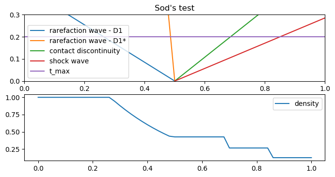

```python
#Sod's test
nx = 51
x = np.linspace(0, 1, nx)
Pl = [1.0, 0., 1.0]
Pr = [0.125, 0.0, 0.1]
xstar = 0.5
t_max = 0.2
#exact solution - matrix (3, nx)
P_exact = riemann_exact_solution(Pl, Pr, pressure_classic_godunov, x, xstar, t_max)

#vận tốc các gián đoạn thu được
wave_speed = np.array([-1.18321596, -0.07027129,  0.92745389,  1.75215261, 1.75215261])

#các đường gián đoạn
def f(x, i): return (x - xstar)/wave_speed[i]
xl = x[:26]
xr = x[25:]
t = np.array([t_max]*nx)

fig = plt.figure(figsize=(8,4), dpi=100)
ax1 = fig.add_subplot(2, 1, 1)
ax2 = fig.add_subplot(2, 1, 2)
ax1.plot(xl, f(xl, 0), xl, f(xl, 1), xr, f(xr, 2), xr, f(xr, 3), x, t)
ax1.legend(['rarefaction wave - D1', 'rarefaction wave - D1*', 'contact discontinuity', 'shock wave', 't_max'])
ax1.axis([0, 1, 0, 0.3])
ax1.set_title("Sod's test")
ax2.plot(x, P_exact[0])
ax2.legend(['density'])
plt.savefig("Sod's_test.png")
plt.show()
```

Kết quả thu được cho ta cái nhìn trực quan hơn về cách lấy nghiệm chính xác. Tiếp theo, ta viết code cho sơ đồ Godunov. Cũng giống như tìm nghiệm chính xác, ta căn cứ vào vị trí của bề mặt giữa hai ô lưới nằm trong vùng nào thì lấy nghiệm trong vùng đó. Để tìm áp suất P (pressure_solver) có thể chọn một trong hai cách đã nêu ở trên: pressure_classic_godunov & pressure_root_finding.

```python
#Giải bài toán phân rã gián đoạn trong trên từng bề mặt thể tích hữu hạn
#phân rã gián đoạn Godunov
def decay_godunov(Pl, Pr, pressure_solver):
    r1, u1, p1 = Pl[0], Pl[1], Pl[2]
    r2, u2, p2 = Pr[0], Pr[1], Pr[2]

    #tìm P, U, R
    P, c1, c2, a1, a2 = pressure_solver(Pl, Pr)
    U = (a1*u1 + a2*u2 + p1 - p2)/(a1 + a2)
    #xét gián đoạn bên trái
    if P > p1: #nếu là sóng xung kích
        D1 = u1 - a1/r1
        R1 = r1*a1/(a1-r1*(u1-U))
    else: #nếu là sóng giãn
        D1 = u1 - c1
        c1star = c1 + gm1d2*(u1-U)
        D1star = U - c1star
        R1 = g*P/c1star**2
    #tương tự cho gián đoạn bên phải
    if P > p2: #nếu là sóng xung kích
        D2 = u2 + a2/r2
        R2 = r2*a2/(a2 + r2*(u2-U))
    else: #nếu là sóng giãn
        D2 = u2 + c2
        c2star = c2 - gm1d2*(u2-U)
        D2star = U + c2star
        R2 = g*P/c2star**2

    #xét cấu hình phân rã xác định nghiệm PStar = (Rstar, Ustar, Pstar)
    #tùy theo vị trí biên i+1/2 nằm trong vùng nào (xem bài 12)

    if D1>0 and D2>0:   #nằm bên trái sóng trái
        Rstar = r1
        Ustar = u1
        Pstar = p1
    elif D1<0 and D2<0: #nằm bên phải sóng phải
        Rstar = r2
        Ustar = u2
        Pstar = p2
    elif D1<0 and D2>0: #nằm giữa hai sóng
        if U>=0: Rstar = R1 #nằm bên trái gián đoạn tiếp xúc
        else:    Rstar = R2 #nằm bên phải gián đoạn tiếp xúc
        Ustar = U
        Pstar = P
    elif D1<0 and D1star>0: #nằm trong sóng giãn trái
        Ustar = gm1dgp1*u1 + c1/gp1d2
        Pstar = p1*np.power(Ustar/c1, g2dgm1)
        Rstar = g*p1/Ustar**2
    elif D2>0 and D2star<0: #nằm trong sóng giãn phải
        Ustar = gm1dgp1*u2 - c2/gp1d2
        Pstar = p2*np.power(Ustar/c2, g2dgm1)
        Rstar = g*p2/Ustar**2
    else:
        print 'Decay Godunov: Error!'

    #vector biến gốc PStar
    PStar = [Rstar, Ustar, Pstar]
    return PStar
```

Để giải hệ phương trình Euler ta cần thêm các hàm chuyển đổi từ biến gốc P sang biến bảo toàn U và ngược lại từ U sang P, hàm chuyển từ biến gốc P sang dòng F.

P, U, F là các ma trận [Nx3] (các bạn có thể chứa dữ liệu ở dạng ma trận [3xN] tùy ý muốn).

```python
#hàm chuyển đổi từ P sang U
def P2U(P, U):
    r, u, p = P[:, 0], P[:, 1], P[:, 2]
    U[:, 0] = r
    U[:, 1] = r*u
    U[:, 2] = r*u**2/2. + p/gm1
    return

#hàm chuyển đổi từ U về P
def U2P(U, P):
    r, ru, re = U[:, 0], U[:, 1], U[:, 2]
    P[:, 0] = r
    P[:, 1] = u = ru/r
    P[:, 2] = (re - ru*u/2.)*gm1
    return

#hàm chuyển đổi từ P sang F
def P2F(P, F):
    r, u, p = P[:, 0], P[:, 1], P[:, 2]
    F[:, 0] = r*u
    F[:, 1] = r*u**2 + p
    F[:, 2] = r*u**3/2. + p*u*gdgm1
    return
```

Hàm tính bước thời gian, hàm tái cấu trúc nghiệm và sơ đồ:

```python
#tính bước thời gian
def time_step(P, CFL, dx):
    r, u, p = P[:, 0], P[:, 1], P[:, 2]
    c = np.sqrt(g*p/r) #vận tốc âm thanh
    u_max = max(abs(u) + c)
    dt = CFL*dx/u_max
    return dt

#tái cấu trúc nghiệm hằng số từng mảnh - Godunov
def godunov_reconstr(Ps):
    P_left = Ps[:-1].copy()
    P_right = Ps[1:].copy()
    return P_left, P_right

#sơ đồ godunov bậc 1
def godunov_method(Ps, pressure_solver, nx, dx, CFL, time_target):
    Us = Ps.copy()
    P2U(Ps, Us)
    Pstar = Ps[:-1].copy()
    Fstar = Ps[:-1].copy()
    time = 0.0
    while(time < time_target):

        #bước 1: tái cấu trúc - reconstruction
        P_left, P_right = godunov_reconstr(Ps)
        #bước 2: tìm nghiệm phân rã gián đoạn, tính hàm dòng
        for i in range(nx-1):
            Pstar[i] = decay_godunov(P_left[i], P_right[i], pressure_solver)
        P2F(Pstar, Fstar)

        #bước 3: tích phân theo thời gian
        dt = time_step(Ps, CFL, dx)
        if(time+dt > time_target): dt = time + dt-time_target
        time += dt

        Us[1:-1] = Us[1:-1] - dt/dx*(Fstar[1:] - Fstar[:-1]) #tìm biến bảo toàn
        U2P(Us, Ps) #tìm biến nguyên thủy

        #điều kiện biên: outflow
        Ps[0] = Ps[1]
        Ps[-1] = Ps[-2]
    return
```

```python
#tìm nghiệm và vẽ đồ thị
def riemann_solver(Pl, Pr, pressure_solver, x, xstar, t_max, CFL, test_name):
    nx = len(x)
    dx = x[1] - x[0] #xét trường hợp lưới đều
    #tạo mảng Ps - matrix (nx, 3)
    Ps = np.zeros((nx, 3))
    Ps[:int(xstar/dx)] = Pl
    Ps[int(xstar/dx):] = Pr

    godunov_method(Ps, pressure_solver, nx, dx, CFL, t_max)
    np.savetxt('data/euler_godunov_'+test_name+'.dat', Ps)

    #exact solution - matrix (3, nx)
    P_exact = riemann_exact_solution(Pl, Pr, pressure_solver, x, xstar, t_max)

    e_godunov   = Ps[:, 2]/(gm1*Ps[:, 0])
    e_exact     = P_exact[2]/(gm1*P_exact[0])

    f, axarr = plt.subplots(2, 2, figsize=(14,10))
    axarr[0, 0].plot(x, Ps[:, 0], x, P_exact[0])
    axarr[0, 0].set_title('density')
    axarr[0, 1].plot(x, Ps[:, 1], x, P_exact[1])
    axarr[0, 1].set_title('velocity')
    axarr[1, 0].plot(x, Ps[:, 2], x, P_exact[2])
    axarr[1, 0].set_title('pressure')
    axarr[1, 1].plot(x, e_godunov, x, e_exact)
    axarr[1, 1].set_title('energy')
    f.subplots_adjust(hspace=0.2)
    plt.legend(['godunov_scheme', 'exact_solution'])
    plt.show()
```

Kiểm tra kết quả bằng 4 bài test:

```python
#chia lưới đều
nx = 51
x = np.linspace(0, 1, nx)

#CFL condition
CFL = 0.9
pressure_solver = pressure_classic_godunov
```

Hãy thay hàm tìm P, tăng nx=1001 và so sánh thời gian tính toán.

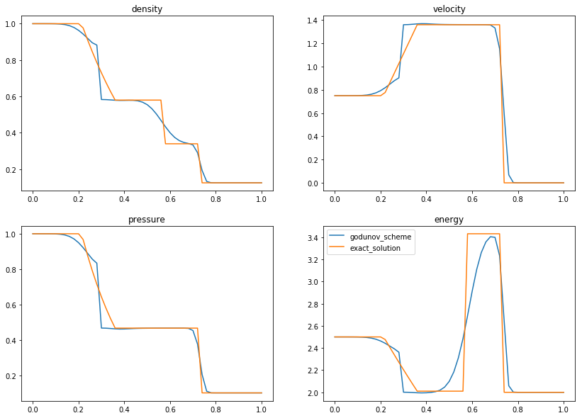

```
CPU times: user 351 ms, sys: 1.01 ms, total: 352 ms
Wall time: 352 ms
```

```python
#test 1
Pl = [1.0, 0.75, 1.0]
Pr = [0.125, 0.0, 0.1]
xstar = 0.3
t_max = 0.2

%time riemann_solver(Pl, Pr, pressure_solver, x, xstar, t_max, CFL, 'test1')
```

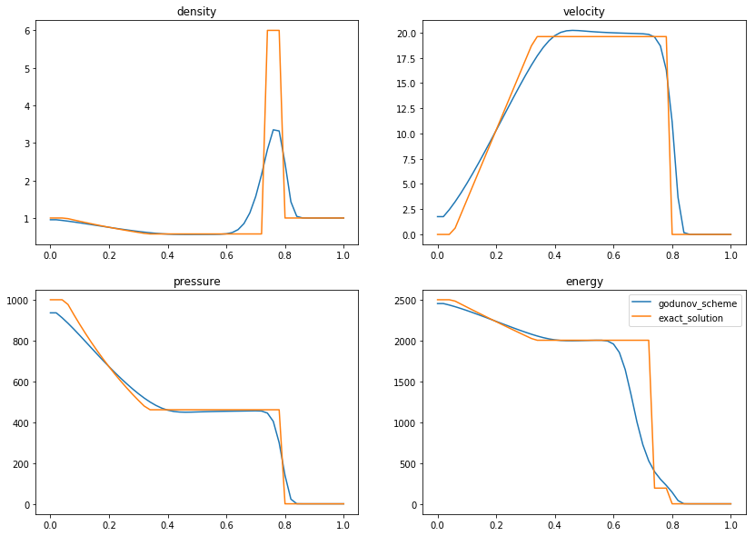

```
CPU times: user 420 ms, sys: 1.88 ms, total: 422 ms
Wall time: 420 ms
```

```python
#test 2
Pl = [1.0, 0.0, 1000.0]
Pr = [1.0, 0.0, 0.01]
xstar = 0.5
t_max = 0.012
%time riemann_solver(Pl, Pr, pressure_solver, x, xstar, t_max, CFL, 'test2')
```

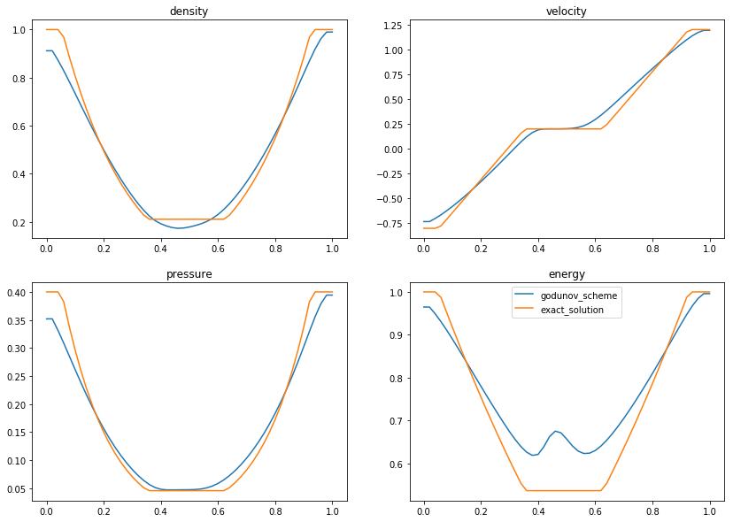

```
CPU times: user 353 ms, sys: 15.6 ms, total: 368 ms
Wall time: 366 ms
```

```python
#test 3
Pl = [1.0, -0.8, 0.4]
Pr = [1.0, 1.2, 0.4]
xstar = 0.44
t_max = 0.25
%time riemann_solver(Pl, Pr, pressure_solver, x, xstar, t_max, CFL, 'test3')
```

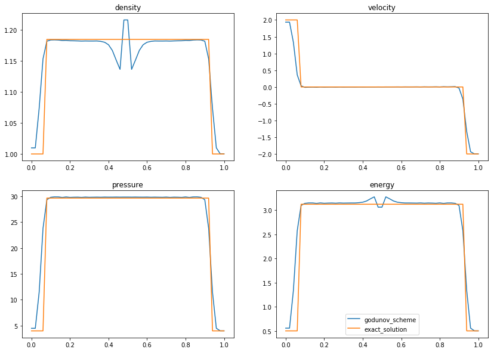

```
CPU times: user 370 ms, sys: 3.17 ms, total: 373 ms
Wall time: 369 ms
```

```python
#test 4
Pl = [1.0, 2.0, 4.0]
Pr = [1.0, -2.0, 4.0]
xstar = 0.5
t_max = 0.04

#lấy gamma = 9.0
g      = 9.0
gp1    = g+1
gm1    = g-1
gp1d2  = (g+1)/2
gm1d2  = (g-1)/2
gp1d2g = (g+1)/(2*g)
gm1d2g = (g-1)/(2*g)
gdgm1  = g/(g-1)
g2dgm1 = g*2/(g-1)
%time riemann_solver(Pl, Pr, pressure_solver, x, xstar, t_max, CFL, 'test4')
```

Chúng ta thấy mỗi bài toàn mang một đặc thù riêng. Chúng sẽ được sử dụng để so sánh giữa các phương pháp khác nhau.

### Bài 17. Euler 1D solver: Godunov, MUSCL, WENO5, Runge-Kutta 3